# Covid Talca, Chile, 2020

Bernardo Pezo

13-11-2022

Análisis sobre el aumento de casos confirmados activos de Covid detectados durante el año 2020, comparando los registros correspondientes a la comuna de Talca con comunas de similar población (+/- 50.000 habitantes) y comunas cercanas.

Se define el periodo 2020 en base a la existencia de datos consolidados, revisados, de origen oficial y públicos.

## Objetivo

Observar el aumento de casos confirmados de Covid desde el primer caso detectado en Chile el 3 de Marzo del 2020, hasta el término del mismo año.

Verificar que existe un comportamiento similar en el aumento de casos confirmados entre comunas cercanas geográficamente y en cantidad de habitantes, con especial enfoque en el comportamiento de la comuna de Talca.

## Preparación

Para el análisis se usarán las librerías:

### tidyvserse

```r
library(tidyverse)
```

### ggplot2

```r
library(ggplot2)
```

## Datos

Datos obtenidos desde el Ministerio de Ciencia y producidos por el Ministerio de Salud (o la fuente que corresponda) https://github.com/MinCiencia/Datos-COVID19

Los datos en los que se enfoca el análisis corresponden al siguiente conjunto:

### Casos confimados activos acumulados.

Conjunto con cantidad acumulada de casos confirmados activos registrados por fecha y comuna.

```r
casos_activos <- read.csv("data/casos_activos.csv")
str(casos_activos)
```

```
## 'data.frame':    50681 obs. of  10 variables:
##  $ Poblacion        : num  247552 247552 247552 247552 247552 ...
##  $ Casos.Confirmados: chr  "6577.0" "24247.0" "11212.0" "26258.0" ...
##  $ Fecha            : chr  "2020/08/24" "2021/05/21" "2021/01/01" "2021/06/11" ...
##  $ Region.ID        : num  15 15 15 15 15 15 15 15 15 15 ...
##  $ Region           : chr  "Arica y Parinacota" "Arica y Parinacota" "Arica y Parinacota" "Arica y Parinacota" ...
##  $ Provincia.ID     : num  151 151 151 151 151 151 151 151 151 151 ...
##  $ Provincia        : chr  "Arica" "Arica" "Arica" "Arica" ...
##  $ Comuna.ID        : num  15101 15101 15101 15101 15101 ...
##  $ Comuna           : chr  "Arica" "Arica" "Arica" "Arica" ...
##  $ Tasa             : chr  "2656.815537745605" "9794.709798345399" "4529.14943123061" "10607.064374353671" ...
```

Quitar registros sin fecha, casos registrados, comuna ni población.

```r
casos_activos <- filter(casos_activos,
    casos_activos$Fecha != "" &
    casos_activos$Poblacion != "" &
    casos_activos$Comuna != "" &
    casos_activos$Casos.Confirmados != "" &
    casos_activos$Casos.Confirmados != "-"
)
```

Normalizar fechas al formato YYYY-MM-DD, población y número de casos como datos tipo enteros.

```r
casos_activos$Fecha <- gsub('/', '-', casos_activos$Fecha)
casos_activos$Fecha <- as.Date(casos_activos$Fecha, format = "%Y-%m-%d")
casos_activos$Casos.Confirmados <- as.numeric(
  as.character(casos_activos$Casos.Confirmados)
)
casos_activos$Poblacion <- as.numeric(
  as.character(casos_activos$Poblacion)
)
```

Recuperar el valor de la población de la comuna de Talca.

```r
poblacion_talca <- filter(casos_activos,
  casos_activos$Comuna == 'Talca'
)
poblacion_talca <- poblacion_talca$Poblacion[1]
print(poblacion_talca)
```

```
## [1] 236724
```

Filtrar solo registros del año 2020, comunas con poblaciones similares a la de Talca y comunas cercanas a Talca.

Comunas consideradas como cercanas:

- Talca
- San Clemente
- Maule
- San Javier
- Pencahue
- San Rafael
- Pelarco

```r
casos_activos <- filter(casos_activos,
  casos_activos$Fecha >= '2020-01-01' &
  casos_activos$Fecha <= '2020-12-31' &
  (
    (
      casos_activos$Poblacion >= (poblacion_talca - 50000) &
      casos_activos$Poblacion <= (poblacion_talca + 50000)
    ) |
    (
      casos_activos$Region == 'Maule' &
        (
          casos_activos$Comuna == 'Talca' |
          casos_activos$Comuna == 'San Clemente' |
          casos_activos$Comuna == 'Maule' |
          casos_activos$Comuna == 'San Javier' |
          casos_activos$Comuna == 'Pencahue' |
          casos_activos$Comuna == 'San Rafael' |
          casos_activos$Comuna == 'Pelarco'
        )
    )
  )
)
```

Ordenar por fecha y cantidad de casos confirmados.

```r
casos_activos <- arrange(casos_activos, Fecha, Casos.Confirmados)
```

Vista previa del conjunto de datos resultantes.

```r
glimpse(casos_activos)
```

```
## Rows: 1,944
## Columns: 10
## $ Poblacion         <dbl> 190336, 249656, 189335, 60000, 9083, 8601, 46292, 49…
## $ Casos.Confirmados <dbl> 0, 0, 0, 0, 0, 0, 0, 0, 0, 5, 6, 7, 11, 16, 17, 17, …
## $ Fecha             <date> 2020-03-30, 2020-03-30, 2020-03-30, 2020-03-30, 202…
## $ Region.ID         <dbl> 2, 4, 13, 7, 7, 7, 7, 7, 7, 1, 15, 6, 8, 13, 4, 13, …
## $ Region            <chr> "Antofagasta", "Coquimbo", "Metropolitana de Santiag…
## $ Provincia.ID      <dbl> 22, 41, 131, 71, 71, 71, 71, 74, 71, 11, 151, 61, 83…
## $ Provincia         <chr> "El Loa", "Elqui", "Santiago", "Talca", "Talca", "Ta…
## $ Comuna.ID         <dbl> 2201, 4101, 13112, 7105, 7106, 7107, 7109, 7406, 711…
## $ Comuna            <chr> "Calama", "La Serena", "La Pintana", "Maule", "Pelar…
## $ Tasa              <chr> "0.0", "0.0", "0.0", "0.0", "0.0", "0.0", "0.0", "0.…
```

Subconjunto de datos contemplando solo la comuna de Talca.

```r
casos_activos_talca <- filter(casos_activos,
  casos_activos$Comuna == "Talca"
)
```

Subconjunto de datos contemplando solo comunas con poblaciones similares a la de Talca.

```r
casos_activos_poblacion <- filter(casos_activos,
  casos_activos$Poblacion >= (poblacion_talca - 50000) &
  casos_activos$Poblacion <= (poblacion_talca + 50000) &
  casos_activos$Comuna != 'Talca'
)
```

Subconjunto de datos contemplando solo comunas cercanas a Talca.

```r
casos_activos_cercano <- filter(casos_activos,
  casos_activos$Region == 'Maule' &
  casos_activos$Comuna != 'Talca' &
    (
      casos_activos$Comuna == 'San Clemente' |
      casos_activos$Comuna == 'Maule' |
      casos_activos$Comuna == 'San Javier' |
      casos_activos$Comuna == 'Pencahue' |
      casos_activos$Comuna == 'San Rafael' |
      casos_activos$Comuna == 'Pelarco'
    )
)
```

## Análisis

Comparación en la variación de casos confirmados detectados entre la comuna de Talca y comunas con similar cantidad de habitantes y cercanas geográficamente.

### Todas las comunas filtradas

Gráfico que muestra los casos confirmados durante el año 2020 en todas las comunas filtradas

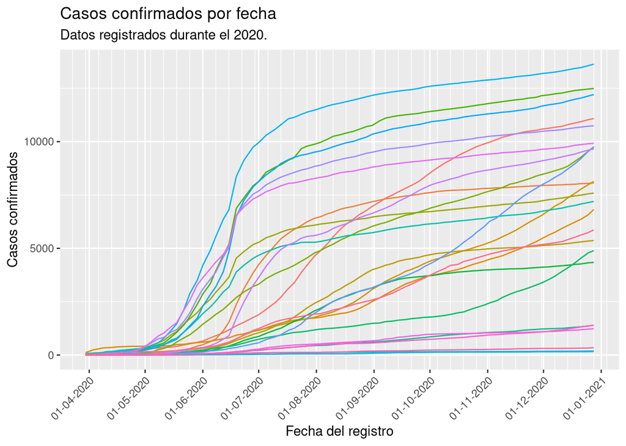

```r
ggplot(data = casos_activos, aes(x = Fecha, y = Casos.Confirmados, group = Comuna, colour = Comuna)) +
  geom_line(show.legend = FALSE) +
  scale_x_date(date_breaks = "1 month", date_minor_breaks = "1 week", date_labels = "%d-%m-%Y") +
  theme(axis.text.x = element_text(angle = 45, vjust = 1, hjust = 1)) +
  labs(title = "Casos confirmados por fecha",
    subtitle = paste0("Datos registrados durante el 2020."),
    x = "Fecha del registro",
    y = "Casos confirmados")
```

Desviación estandar, promedio, mediana, máximo y mínimo.

```r
sd(casos_activos$Casos.Confirmados)
```

```
## [1] 3887.822
```

```r
mean(casos_activos$Casos.Confirmados)
```

```
## [1] 3543.642
```

```r
median(casos_activos$Casos.Confirmados)
```

```
## [1] 1573
```

```r
max(casos_activos$Casos.Confirmados)
```

```
## [1] 13630
```

```r
min(casos_activos$Casos.Confirmados)
```

```
## [1] 0
```

### Comuna de Talca

Gráfico que muestra los casos confirmados durante el año 2020 en la comuna de Talca.

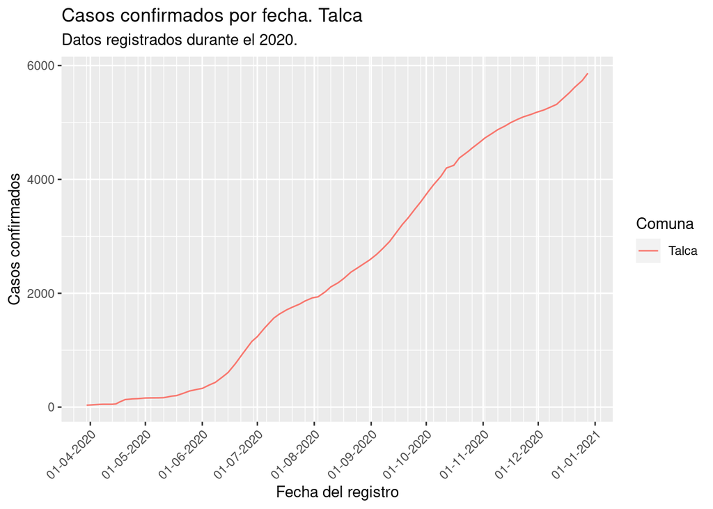

```r
ggplot(data = casos_activos_talca, aes(x = Fecha, y = Casos.Confirmados, group = Comuna, colour = Comuna)) +
  geom_line() +
  scale_x_date(date_breaks = "1 month", date_minor_breaks = "1 week", date_labels = "%d-%m-%Y") +
  theme(axis.text.x = element_text(angle = 45, vjust = 1, hjust = 1)) +
  labs(title = "Casos confirmados por fecha. Talca",
    subtitle = paste0("Datos registrados durante el 2020."),
    x = "Fecha del registro",
    y = "Casos confirmados")
```

Desviación estandar, promedio, mediana, máximo y mínimo.

```r
sd(casos_activos_talca$Casos.Confirmados)
```

```
## [1] 1978.276
```

```r
mean(casos_activos_talca$Casos.Confirmados)
```

```
## [1] 2411.272
```

```r
median(casos_activos_talca$Casos.Confirmados)
```

```
## [1] 2112
```

```r
max(casos_activos_talca$Casos.Confirmados)
```

```
## [1] 5865
```

```r
min(casos_activos_talca$Casos.Confirmados)
```

```
## [1] 34
```

### Comunas con poblaciones similares a la de Talca

Gráfico que muestra los casos confirmados durante el año 2020 en comunas con poblaciones similares a la de Talca.

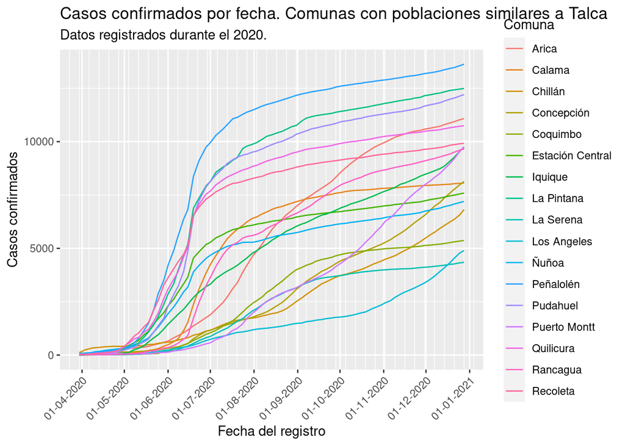

```r
ggplot(data = casos_activos_poblacion, aes(x = Fecha, y = Casos.Confirmados, group = Comuna, colour = Comuna)) +
  geom_line() +
  scale_x_date(date_breaks = "1 month", date_minor_breaks = "1 week", date_labels = "%d-%m-%Y") +
  theme(axis.text.x = element_text(angle = 45, vjust = 1, hjust = 1)) +
  labs(title = "Casos confirmados por fecha. Comunas con poblaciones similares a Talca",
    subtitle = paste0("Datos registrados durante el 2020."),
    x = "Fecha del registro",
    y = "Casos confirmados")
```

Desviación estandar, promedio, mediana, máximo y mínimo.

```r
sd(casos_activos_poblacion$Casos.Confirmados)
```

```
## [1] 3983.753
```

```r
mean(casos_activos_poblacion$Casos.Confirmados)
```

```
## [1] 4747.566
```

```r
median(casos_activos_poblacion$Casos.Confirmados)
```

```
## [1] 4358
```

```r
max(casos_activos_poblacion$Casos.Confirmados)
```

```
## [1] 13630
```

```r
min(casos_activos_poblacion$Casos.Confirmados)
```

```
## [1] 0
```

### Comunas cercanas a la de Talca

Gráfico que muestra los casos confirmados durante el año 2020 en comunas cercanas a la de Talca.

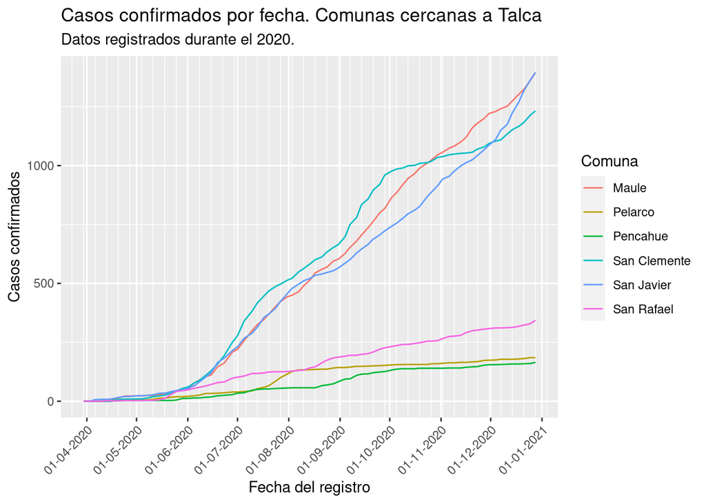

```r
ggplot(data = casos_activos_cercano, aes(x = Fecha, y = Casos.Confirmados, group = Comuna, colour = Comuna)) +
  geom_line() +
  scale_x_date(date_breaks = "1 month", date_minor_breaks = "1 week", date_labels = "%d-%m-%Y") +
  theme(axis.text.x = element_text(angle = 45, vjust = 1, hjust = 1)) +
  labs(title = "Casos confirmados por fecha. Comunas cercanas a Talca",
    subtitle = paste0("Datos registrados durante el 2020."),
    x = "Fecha del registro",
    y = "Casos confirmados")
```

Desviación estandar, promedio, mediana, máximo y mínimo.

```r
sd(casos_activos_cercano$Casos.Confirmados)
```

```
## [1] 384.9842
```

```r
mean(casos_activos_cercano$Casos.Confirmados)
```

```
## [1] 321.251
```

```r
median(casos_activos_cercano$Casos.Confirmados)
```

```
## [1] 148
```

```r
max(casos_activos_cercano$Casos.Confirmados)
```

```
## [1] 1395
```

```r
min(casos_activos_cercano$Casos.Confirmados)
```

```
## [1] 0
```

## Conclusiones

En base a los resultados calculados, se puede afirmar que la comuna de Talca tuvo un aumento menor que el de otras comunas con poblaciones similares, pero mayor en comparación a comunas cercanas.

A pesar de que ninguna de las comunas cercanas tiene poblaciones similares a la de Talca, se asume que producto de su cercanía geográfica, poblaciones considerablemente menores y el hecho de que Talca es la capital regional, existe un gran flujo de personas entre las comunas.

El hecho de que la comuna de Talca haya tenido un aumento menor que otras comunas con problaciones similares, puede se producto de que muchas de estas comunas pertenecen a la Región Metropolitana, donde existe un alto flujo de personas entre comunas con altas poblaciones.